# dCovTS: Distance Covariance/Correlation for Time Series

The ACF plots of the original series (upper panel of Figure 3) suggest no serial correlation among observations, while the ACF plots of the squared series (upper panel of Figure 4) imply strong dependence. This confirms the conditional heteroscedasticity in the monthly log returns. However, the ADCF plots for both original and squared series (lower panels of Figures 3 and 4) suggest dependence. Indeed, choosing $p=\left[3n^\lambda\right]$ for $\lambda=0.1$, $0.2$ and $0.3$, that is $p = 6$, $12$ and $22$, and employing Bartlett kernel, $\overline{T}_n$ gives low $p$-values ($0.022$, $0.014$ and $0.020$ respectively). The calls for these three multivariate tests of independence can be found below (they take about 2, 3 and 6 minutes respectively for $b=499$ bootstrap replications on a standard laptop with Intel Core i5 system and CPU 2.30 GHz):

```r
mADCFtest(at, "bartlett", p = 6, b = 499, parallel = TRUE)

##        Multivariate test of independence based on distance correlation
##
## data:  at, kernel type: bartlett, bandwidth=6, boot replicates 499
## Tnbar = 34.1743, p-value = 0.022

mADCFtest(at, "bartlett", p = 12, b = 499, parallel = TRUE)

##        Multivariate test of independence based on distance correlation
##
## data:  at, kernel type: bartlett, bandwidth=12, boot replicates 499
## Tnbar = 71.1713, p-value = 0.014

mADCFtest(at, "bartlett", p = 22, b = 499, parallel = TRUE)

##        Multivariate test of independence based on distance correlation
##
## data:  at, kernel type: bartlett, bandwidth=22, boot replicates 499
## Tnbar = 122.9424, p-value = 0.02
```

```r
> library(portes)
> LjungBox(at, c(6, 12, 22))
```

Assuming that the bivariate log returns follows a VAR model and employing the AIC to choose its best order, we obtain that a VAR(2) model fits the data well. Figure 5 shows the ACF plots (upper panel) and ADCF plots (lower panel) of the residuals after fitting a VAR(2) model to the original bivariate log return series using the function `VAR()` from the [*MTS*](https://CRAN.R-project.org/package=MTS) (Tsay 2015) package.

(a)

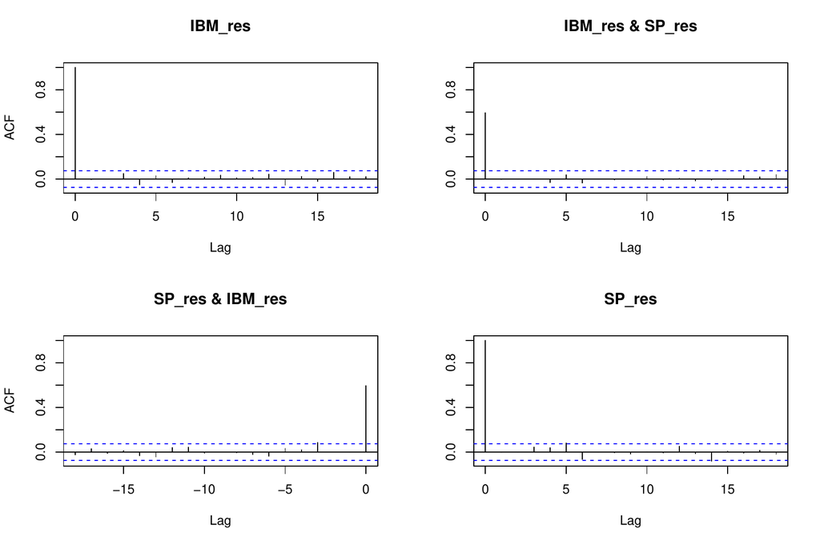

(b)

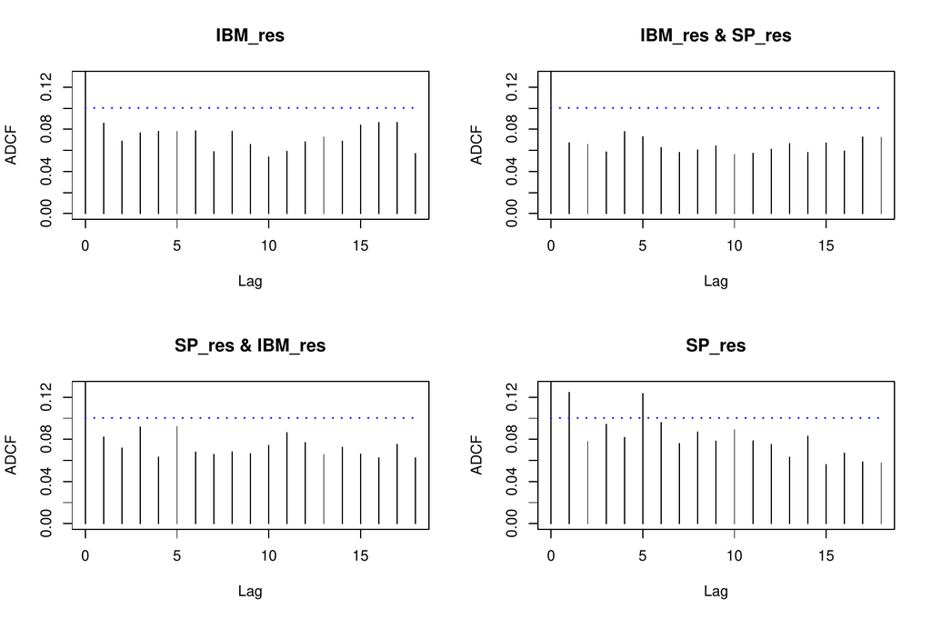

Figure 5: (a) The sample ACF and (b) sample ADCF of the residuals after fitting VAR(2) model to the original series.

In contrast to the ACF plot, the ADCF plot still indicates some dependence among the residuals. Constructing tests of independence based on $\overline{T}_n$ and $mLB$ for the same choices of bandwidth, $p=6$, $12$, $22$, we confirm this visual result. In particular, employing a Bartlett kernel, $\overline{T}_n$ statistic gives low $p$-values ($0.036$, $0.018$ and $0.034$ respectively) whereas the $mLB$ statistic yields large $p$-values ($0.669$, $0.958$ and $0.806$ respectively). The calls for the plots of Figure 5 and the corresponding tests of independence are as follows:

```r
library(MTS)
model <- VAR(at, 2)
resids <- residuals(model)
colnames(resids) <- c("IBM_res", "SP_res")
windows(9, 6)
acf(resids, lag.max = 18)
mADCFplot(resids, MaxLag = 18, ylim = c(0, 0.13))

## Tests of independence based on \overline{T}_n
mADCFtest(resids, "bartlett", p = 6, b = 499, parallel = TRUE)

##         Multivariate test of independence based on distance correlation
##
## data:  resids, kernel type: bartlett, bandwidth=6, boot replicates 499
## Tnbar = 29.9114, p-value = 0.036

mADCFtest(resids, "bartlett", p = 12, b = 499, parallel = TRUE)

##         Multivariate test of independence based on distance correlation
##
## data:  resids, kernel type: bartlett, bandwidth=12, boot replicates 499
## Tnbar = 64.7754, p-value = 0.018

mADCFtest(resids, "bartlett", p = 22, b = 499, parallel = TRUE)

##        Multivariate test of independence based on distance correlation
##
## data:  resids, kernel type: bartlett, bandwidth=22, boot replicates 499
## Tnbar = 115.3462, p-value = 0.034

## Tests of independence based on mLB
LjungBox(resids, c(6, 12, 22))
```

## 9 Summary and further research

There have been many works in the literature based on (Székely, M. L. Rizzo, and N. K. Bakirov 2007) distance covariance methodology. The R package *energy* (Rizzo and G. J. Szekely 2014), provides functions that cover this methodology. However, there is no published package that includes functions about distance covariance for time series data. *dCovTS* contributes to filling this gap by providing functions that compute distance covariance and correlation functions for both univariate and multivariate time series. We also include functions that develop univariate and multivariate tests of serial dependence based on distance covariance and correlation functions.

There is a number of possible extensions of this package, and some of them are not covered by existing theory and can be seen as further research. One possible direction is to develop a theory based on partial ADCV or conditional ADCV and a related testing methodology to identify possible dependencies among time series (see Székely and M. L. Rizzo (2014) for partial distance covariance methodology and Poczos and J. Schneider (2012), Wang, W. Pan, W. Hu, Y. Tian, and H. Zhang (2015) for conditional distance covariance methodology; all three works deal with independent random variables). Among the many applications of partial correlation are graphical models. Thus, a graphical modeling theory based on partial ADCV could be carried out and this methodology can be included for a future version of this package.

## 10 Acknowledgments

The authors thank Tobias Liboschik for his considerable help on the development of this package. The authors would also like to thank Dominic Edelmann for carefully checking the package and making helpful comments and suggestions for its improvement. In addition, we would like to extend our gratitude to R. Bivand and to an anonymous reviewer whose comments improved our original submission.

### 10.1 CRAN packages used

energy, doParallel, portes, MTS

### 10.2 CRAN Task Views implied by cited packages

TimeSeries

R. Analytics and S. Weston. *doParallel: Foreach Parallel Adaptor for the ’parallel’ Package, .* R package version 1.0.10, 2015. URL http://CRAN.R-project.org/package=doParallel.

G. E. P. Box and D. A. Pierce. *Distribution of residual autocorrelations in autoregressive-integrated moving average time series models.* Journal of the American Statistical Association 65:, 1970.

R. A. Davis, M. Matsui, T. Mikosch, and P. Wan. *Applications of distance correlation to time series.* 2016. URL http://arxiv.org/abs/1606.05481.

H. Dehling and T. Mikosch. *Random quadratic forms and the boostrap for U-statistics.* Journal of Multivariate Analysis 51:, 1994.

J. Dueck, D. Edelmann, T. Gneiting, and D. Richards. *The affinely invariant distance correlation.* Bernoulli 20:, 2014.

A. Feuerverger. *A consistent test for bivariate dependence.* International Statistical Review 61:, 1993.

K. Fokianos and M. Pitsillou. *Consistent testing for pairwise dependence in time series.* Technometrics natexlaba, 2016a. URL http://dx.doi.org/10.1080/00401706.2016.1156024.

K. Fokianos and M. Pitsillou. *Testing pairwise independence for multivariate time series by the auto-distance correlation matrix.* Submitted for publication natexlabb, 2016b.

A. Gretton, K. Fukumizu, and B. K. Sriperumbudur. *Discussion of: Brownian distance covariance.* The Annals of Applied Statistics 3:, 2009.

Y. Hong. *Consistent testing for serial correlation of unknown form.* Econometrica 64:, 1996.

Y. Hong. *Hypothesis testing in time series via the emprical characteristic function: A generalized spectral density approach.* Journal of the American Statistical Association 94:, 1999.

J. R. M. Hosking. *Multivariate Portmanteau statistic.* Journal of the American Statistical Association 75:, 1980.

J. Josse and S. Holmes. *Tests of independence and beyond.* 2014. URL http://arxiv.org/pdf/1307.7383.pdf.

A. Leucht and M. H. Neumann. *Degenerate U- and V-statistics under ergodicity: asymptotics, bootstrap and applications in statistics.* Annals of the Institute of Statistical Mathematics,65: natexlaba, 2013a.

A. Leucht and M. H. Neumann. *Dependent wild bootstrap for degenerate U- and V- statistics.* Journal of Multivariate Analysis 117: ,natexlabb, 2013b.

G. M. Ljung and G. E. P. Box. *On a measure of lack of fit in time series models.* Biometrika 62:, 1978.

E. Mahdi and A. I. McLeod. *Improved multivariate Portmanteau diagnostic test.* Journal of Time Series Analysis 33:, 2012. URL http://onlinelibrary.wiley.com/doi/10.1111/j.1467-9892.2011.00752.x/abstract.

E. Parzen. *On consistent estimates of the spectrum of a stationary time series.* Annals of Mathematical Statistics 28:, 1957.

B. Poczos and J. Schneider. *Conditional distance variance and correlation.* bapoczos/articles/poczos12distancecorr.pdf, 2012. URL http://www.cs.cmu.edu/.

N. P. Politis, J. P. Romano, and M. Wolf. *Subsampling.* Springer-Verlag New York, 1999.

B. Remillard. *Discussion of: Brownian distance covariance.* The Annals of Applied Statistics 3:, 2009.

M. L. Rizzo and G. J. Szekely. *energy: E-statistics (energy statistics), .* R package version 1.6.2, 2014. URL https://CRAN.R-project.org/package=energy.

X. Shao. *The dependent wild bootstrap.* Journal of the American Statistical Association 105:, 2010.

R. H. Shumway and D. S. Stoffer. *Time Series Analysis and Its Applications With R Examples.* Springer-Verlag New York Third Edition, 2011.

R. H. Shumway, R. S. Azari, and Y. Pawitan. *Modeling mortality fluctuations in Los Angeles as functions of pollution and weather effects.* Environmetnal research 45:, 1988.

G. J. Székely and M. L. Rizzo. *Partial distance correlation with methods for dissimilarities.* The Annals of Statistics 42:, 2014.

G. J. Székely, M. L. Rizzo, and N. K. Bakirov. *Measuring and testing dependence by correlation of distances.* The Annals of Statistics 35:, 2007.

R. S. Tsay. *Analysis of Financial Time Series.* Wiley Series in Probability; Statistics Hoboken NJ Third Edition, 2010.

R. S. Tsay. *MTS: All-Purpose Toolkit for Analyzing Multivariate Time Series (MTS) and Estimating Multivariate Volatility Models, .* R package version 0.33, 2015. URL http://CRAN.R-project.org/package=MTS.

R. S. Tsay. *Multivariate Time Series Analysis With R and Financial Applications.* Wiley Series in Probability; Statistics Hoboken NJ, 2014.

X. Wang, W. Pan, W. Hu, Y. Tian, and H. Zhang. *Conditional distance correlation.* Journal of the American Statistical Association DOI: 10.1080/01621459.2014.993081, 2015.

C. F. J. Wu. *Jackknife, bootstrap and other resampling methods in regression analysis.* The Annals of Statistics 14:, 1986.

Z. Zhou. *Measuring nonlinear dependence in time-series, a distance correlation approach.* Journal of Time Series Analysis 33:, 2012.